# Tugas Pertemuan 6 dan 7

### ARIMA(3,1,1)

```r
model7.da=Arima(train.diff, order=c(3,1,1),method="ML")
summary(model7.da) #AIC=2015.21
```

```
## Series: train.diff
## ARIMA(3,1,1)
##
## Coefficients:
##          ar1      ar2      ar3      ma1
##       0.1571  -0.0293  -0.0129  -0.9999
## s.e.  0.0921   0.0926   0.0921   0.0251
##
## sigma^2 = 1399181:  log likelihood = -1002.61
## AIC=2015.21   AICc=2015.75   BIC=2029.07
##
## Training set error measures:
##                     ME     RMSE      MAE MPE MAPE      MASE         ACF1
## Training set -22.52129 1157.753 588.1541 NaN  Inf 0.7344147 -0.006131037
```

```r
lmtest::coeftest(model7.da) # tidak seluruh parameter signifikan
```

```
##
## z test of coefficients:
##
##      Estimate Std. Error  z value Pr(>|z|)
## ar1  0.157125   0.092056   1.7068  0.08785 .
## ar2 -0.029317   0.092566  -0.3167  0.75146
## ar3 -0.012877   0.092147  -0.1397  0.88886
## ma1 -0.999882   0.025094 -39.8448  < 2e-16 ***
## ---
## Signif. codes:  0 '***' 0.001 '**' 0.01 '*' 0.05 '.' 0.1 ' ' 1
```

Berdasarkan pendugaan parameter di atas, nilai AIC terkecil dimiliki oleh model ARIMA(2,1,3) dan parameter model ARIMA(2,1,3) juga seluruhnya signifikan sehingga model yang dipilih adalah model ARIMA(2,1,3).

## Analisis Sisaan

Model terbaik hasil identifikasi kemudian dicek asumsi sisaannya. Sisaan model ARIMA harus memenuhi asumsi normalitas, kebebasan sisaan, dan kehomogenan ragam. Diagnostik model dilakukan secara eksplorasi dan uji formal.

### Eksplorasi Sisaan

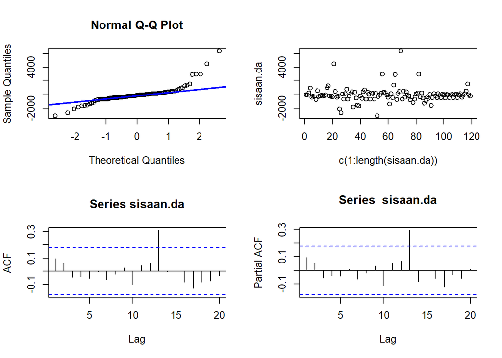

```r
#Eksplorasi
sisaan.da <- model6.da$residuals
par(mfrow=c(2,2))
qqnorm(sisaan.da)
qqline(sisaan.da, col = "blue", lwd = 2)
plot(c(1:length(sisaan.da)),sisaan.da)
acf(sisaan.da)
pacf(sisaan.da)
```

```r
par(mfrow = c(1,1))
```

Berdasarkan plot kuantil-kuantil normal, secara eksplorasi ditunjukkan sisaan tidak menyebar normal ditandai dengan titik titik yang cenderung tidak mengikuti garis $45^{\circ}$. Kemudian dapat dilihat juga lebar pita sisaan yang cenderung tidak sama menandakan bahwa sisaan memiliki ragam yang heterogen. Plot ACF dan PACF sisaan ARIMA(2,1,3) juga signifikan pada lag 13 yang menandakan tidak saling bebas. Kondisi ini akan diuji lebih lanjut dengan uji formal.